# Part II - (The Impact of Time on Barcelona's Street Accidents)

## by (Andric Ishami)

## Investigation Overview

> In this investigation, I wanted to see the influence time (that is month, day, hour, season or year) has on the number and dimension of accidents happening in Barcelona.

## Distribution of Accidents In Barcelona In Months

> Accidents in Barcelona are observed to increase in the end of year (with a peak in October) and the start of year. Once plotted in a month ordered way, the pattern seems easy to notice.

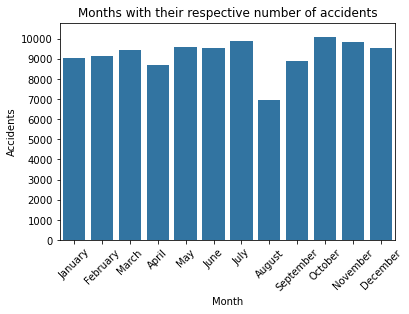

## Time of Day and Accidents in Barcelona

> Most of the accidents that happened in the last 10 years happened mostly in the afternoon. A bar chart comparing other time of a day makes this easy to notice.

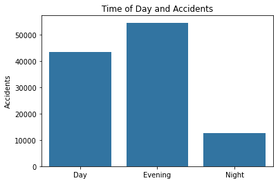

## Hour of Time and Accidents

> Barcelona being on of the most touristic places in the world, one may wonder if certain busy hours of the day means frequent accidents. It turns out that it's in the afternoon when the streets are busy in Barcelona that most accidents are noticed.

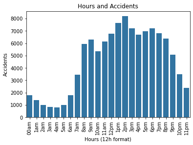

## Time of Day vs Size of Accident

> Do the size of accidents vary depending on what time of the day it is? Plotting the number ofvehicles involved in each accident with the time of the day gives us a hint. The bigger the number of cars in an accident, the bigger the scope/dimension of the accident.

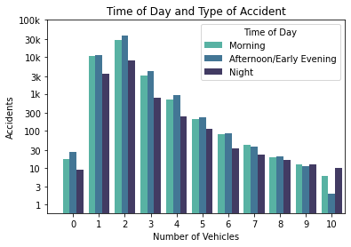

## Number of Deaths vs Seasons from 2010 to 2021

The seasons play an important role in a touristic city such as Barcelona, but is it influential on the deaths from street accidents? I also wanted to see how had this influence been looking for the past 10 years.

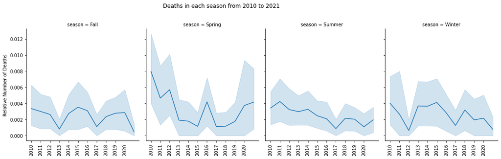